# CSE204 - Introduction to Machine Learning - Lab Session 5 - Exam

# Exercise 2: logistic regression

The logistic regression is a common model used to perform binary classification that is actually formulated as a regression problem.

We have a *learning / training set* $\mathcal{D} = \{\boldsymbol{x^{(i)}}, y^{(i)}\}_{1 \leq i \leq n}$, where $y_i \in \{0,1\}$ and $x_i \in \mathbb{R}^p$.

We consider the logistic / sigmoid function: $$ \sigma : t \mapsto \frac{1}{1 + e^{-t}}.$$ Note that $\sigma$ takes values in $(0,1)$ and will be used to estimate $y^{(i)}$ given $x^{(i)}$. More precisely, given a weight vector $\theta = ( \theta_0, \dots, \theta_p )^T$ and a vector $x^{(i)} = (1, x^{(i)}_1, \dots ,x^{(i)}_p)^T$, we make the following estimation: $$ \hat{y}^{(i)} = \begin{cases} 1 \text{ if } \sigma(x^{(i)T} \theta) > 1/2 \\ 0 \text{ otherwise } \end{cases} $$

We want to find a good $\theta$. One can show that the optimal (in the sense of the *likelihood*) $\boldsymbol{\theta}^* = \begin{pmatrix} \theta_0^* & \dots & \theta_p^* \end{pmatrix}^T$ minimizes the following optimization problem:

$$\boldsymbol{\theta}^* \leftarrow {\arg\!\min}_{\boldsymbol{\theta}} E(\boldsymbol{\theta}) \quad \text{with} \quad E(\boldsymbol{\theta}) = - \sum_{i=1}^n (1 − y^{(i)}) \ln(1 − \sigma^{(i)}) + (y^{(i)}) \ln(\sigma^{(i)})$$

and

$$ \boldsymbol{X} = \begin{pmatrix} 1 & x_1^{(1)} & \dots & x_p^{(1)} \\ \vdots & \vdots & \dots & \vdots \\ 1 & x_1^{(n)} & \dots & x_p^{(n)} \end{pmatrix} \quad \quad \boldsymbol{y} = \begin{pmatrix} y^{(1)} \\ \vdots \\ y^{(n)} \end{pmatrix} \quad \quad \boldsymbol{\theta} = \begin{pmatrix} \theta_0 \\ \vdots \\ \theta_p \end{pmatrix} $$

**Question 1: (0.5pt)** Does the error function $E$ have a unique minimum? Why? If it exists, is there an analytical (closed form) solution corresponding to this minimum?

$E(\theta)$ is convex (as a composition of convex / - concave functions) so it has a unique minimum.

We cannot obtain a closed form solution by setting the gradient to $O$ since the parameters enter this set of equations in a non-linear way.

### Iris dataset

We now consider the `iris` dataset of $n = 150$ points, with $3$ labels 'setosa', 'versicolor', and 'virginica', encoded respectively by $0, 1, 2$ in the following. This dataset is split in a training set `x_train, y_train` with $3/4$th of the $150$ observations, and a test set `x_test, y_test` of $1/4$th of the $150$ observations; this dataset must be loaded by running the following cell.

```python
iris = datasets.load_iris()
X = iris.data[:, :2][np.where([target in [0, 1] for target in iris.target])[0]]
y = iris.target[np.where([target in [0, 1] for target in iris.target])[0]]
np.random.seed(seed=1)
x_train, x_test, y_train, y_test = sk.model_selection.train_test_split(X,
                                                                       y,
                                                                       test_size=1/4,
                                                                       random_state=1)
```

The description of this dataset (not mandatory for what follows - note that we've kept only the two first features, sepal length and sepal width).

```python
print(iris.DESCR)
```

```
.. _iris_dataset:

Iris plants dataset
--------------------

**Data Set Characteristics:**

    :Number of Instances: 150 (50 in each of three classes)
    :Number of Attributes: 4 numeric, predictive attributes and the class
    :Attribute Information:
        - sepal length in cm
        - sepal width in cm
        - petal length in cm
        - petal width in cm
        - class:
                - Iris-Setosa
                - Iris-Versicolour
                - Iris-Virginica

    :Summary Statistics:

    ============== ==== ==== ======= ===== ====================
                    Min  Max   Mean    SD   Class Correlation
    ============== ==== ==== ======= ===== ====================
    sepal length:   4.3  7.9   5.84   0.83    0.7826
    sepal width:    2.0  4.4   3.05   0.43   -0.4194
    petal length:   1.0  6.9   3.76   1.76    0.9490  (high!)
    petal width:    0.1  2.5   1.20   0.76    0.9565  (high!)
    ============== ==== ==== ======= ===== ====================

    :Missing Attribute Values: None
    :Class Distribution: 33.3% for each of 3 classes.
    :Creator: R.A. Fisher
    :Donor: Michael Marshall (MARSHALL%PLU@io.arc.nasa.gov)
    :Date: July, 1988

The famous Iris database, first used by Sir R.A. Fisher. The dataset is taken
from Fisher's paper. Note that it's the same as in R, but not as in the UCI
Machine Learning Repository, which has two wrong data points.

```

[output cut: 8 more lines]

```

   - Fisher, R.A. "The use of multiple measurements in taxonomic problems"
     Annual Eugenics, 7, Part II, 179-188 (1936); also in "Contributions to
     Mathematical Statistics" (John Wiley, NY, 1950).
   - Duda, R.O., & Hart, P.E. (1973) Pattern Classification and Scene Analysis.
     (Q327.D83) John Wiley & Sons.  ISBN 0-471-22361-1.  See page 218.
   - Dasarathy, B.V. (1980) "Nosing Around the Neighborhood: A New System
     Structure and Classification Rule for Recognition in Partially Exposed
     Environments".  IEEE Transactions on Pattern Analysis and Machine
     Intelligence, Vol. PAMI-2, No. 1, 67-71.
   - Gates, G.W. (1972) "The Reduced Nearest Neighbor Rule".  IEEE Transactions
     on Information Theory, May 1972, 431-433.
   - See also: 1988 MLC Proceedings, 54-64.  Cheeseman et al"s AUTOCLASS II
     conceptual clustering system finds 3 classes in the data.
   - Many, many more ...
```

10 first rows of `x_train`:

```python
x_train[:10]
```

```
array([[5. , 3.2],
       [5.6, 2.7],
       [5.2, 3.5],
       [5.1, 3.8],
       [4.4, 3. ],
       [5.8, 2.7],
       [5.7, 2.8],
       [6.5, 2.8],
       [5.7, 3. ],
       [5.6, 3. ]])
```

The corresponding labels (corresponding resp. to 'setosa', 'versicolor', and 'virginica').

```python
y_train[:10].reshape(-1, 1)
```

```
array([[0],
       [1],
       [0],
       [0],
       [0],
       [1],
       [1],
       [1],
       [1],
       [1]])
```

**Question 2:**

**2.a. (1pt)** Implement a function `sigma` which computes, given $x \in \mathbb{R}^p$ and $\theta \in \mathbb{R}^{p+1}$ the quantity $\sigma(x^{T} \theta)$.

*Python hints* :

- You can use `np.exp(...)` to compute the exponential.
- You can use `np.concatenate((A, B))` to concatenate two numpy arrays.
- You can use `np.dot(A,B)`, or equivalently `A.dot(B)` to compute the matrix-matrix (or matrix-vector) $A \cdot B$ product between two numpy arrays `A` and `B`. Equivalently, you can use matrix multiplication with vectors (either `A @ B` or `np.matmul(A, B)`), but beware of the shapes!

```python
def sigma(x: np.array, theta: np.array) -> float:
    """
    Compute the sigmoid function

    :param numpy.array x: input vector shape p
    :param numpy.array theta: parameter vector of shape (p + 1)
    :return: probability for class 1
    :rtype: float
    """
    ### BEGIN SOLUTION
    # We add the bias term to x vector (IMPORTANT!).
    # Then, we compute a dot product of extended x vector and theta vector.
    # Finally, we compute the value of sigmoid function.
    if x.ndim == 1:  # single sample version (perfectly fine)
        return 1 / (1 + np.exp(-np.dot(np.concatenate((np.array([1]), x), 0), theta)))
    else:
        return 1 / (1 + np.exp(-np.dot(np.column_stack((np.ones(x.shape[0]), x)), theta)))
    ### END SOLUTION
```

```python
assert sigma(X[0,:], np.array([0, 0, 0])) == 0.5
### BEGIN HIDDEN TESTS
assert round(sigma(X[0, :], np.array([1, 1, 1])), 1) == 1
### END HIDDEN TESTS
```

**2.b. (1pt)** Implement a function `pred` which provides, given $x \in \mathbb{R}^p$ and $\theta \in \mathbb{R}^{p+1}$, an estimate $\hat{y}$ of $y$ as defined above.

```python
def pred(x: np.array, theta: np.array) -> int:
    """
    Compute a class prediction from a class probability

    :param numpy.array x: input vector of shape p
    :param numpy.array theta: parameter vector of shape p + 1
    :return: predicted class
    :rtype: int
    """
    ### BEGIN SOLUTION
    # We program the threshold.
    # We return 1 if the value of sigma is higher than 0.5, 0 otherwise.
    return 1 if sigma(x, theta) > 1/2 else 0
    ### END SOLUTION
```

```python
assert pred(X[0,:], np.array([1,1,1])) == 1  # Test for a particular value
### BEGIN HIDDEN TESTS
assert pred(X[0,:], np.array([-1,-1,-1])) == 0
### END HIDDEN TESTS
```

**Question 3 (1pt):** Implement the error function $E$ defined above, and which we want to subsequently minimize w.r.t. $\theta$. It takes $X, y, \theta$ as arguments.

```python
def E(X: np.array, y: np.array, theta: np.array) -> float:
    """
    Compute error for logistic regression

    :param numpy.array X: design matrix of shape N x p
    :param numpy.array y: vector of real classes of shape N
    :param numpy.array theta: parameter vector of shape (p+1)
    :return: error
    :rtype: float
    """
    ### BEGIN SOLUTION
    # We initialize loss variable to 0.
    # We apply the loss function definition as stated in the problem.
    # Note that -= comes from the - in the definition of E function.
    return (- (1 - y) * np.log(1 - sigma(X, theta)) - y * np.log(sigma(X, theta))).sum()
    loss = 0
    for i in range(X.shape[0]):
        loss -= (1 - y[i]) * np.log(1 - sigma(X[i, :], theta)) + y[i] * np.log(sigma(X[i, :], theta))
    return loss
    ### END SOLUTION
```

```python
print(E(X, y, np.array([0, 0, 0])))  # Prints a particular value
### BEGIN HIDDEN TESTS
assert int(E(X, y, np.array([0, 0, 0]))) == 69
assert int(E(X, y, np.array([1, 1, 1]))) == 471
### END HIDDEN TESTS
```

```
69.31471805599453
```

As there is no closed form for the optimal $\theta^*$, we will minimize $E$ using a gradient descent. Compute, either here or on a separate sheet of paper (upload it in a **new** Markdown cell via Edit > Insert Image), the **analytical expression** (as opposed to a particular value given some particular inputs $\boldsymbol{X}, \boldsymbol{y}$) gradient of $E$ w.r.t. $\boldsymbol{X}, \boldsymbol{y}, \theta$.

Recall:

$$ (\boldsymbol{A} + \boldsymbol{B})^T = \boldsymbol{A}^T + \boldsymbol{B}^T $$$$ (\boldsymbol{A} \boldsymbol{B})^T = \boldsymbol{B}^T \boldsymbol{A}^T $$\begin{align} \text{Associativity:} & \quad (\boldsymbol{A} \boldsymbol{B}) \boldsymbol{C} = \boldsymbol{A} (\boldsymbol{B} \boldsymbol{C}) = \boldsymbol{A} \boldsymbol{B} \boldsymbol{C} \\ \text{Non-commutativity:} & \quad \boldsymbol{A} \boldsymbol{B} \neq \boldsymbol{B} \boldsymbol{A} \\ \text{Distributivity:} & \quad \boldsymbol{A} (\boldsymbol{B} + \boldsymbol{C}) = \boldsymbol{A} \boldsymbol{B} + \boldsymbol{A} \boldsymbol{C} \\ & \quad (\boldsymbol{B} + \boldsymbol{C}) \boldsymbol{A} = \boldsymbol{B} \boldsymbol{A} + \boldsymbol{C} \boldsymbol{A} \end{align}

Differential identities for matrices:

\begin{align} d(\boldsymbol{A}) & = 0 \quad \quad \quad \text{if } \boldsymbol{A} \text{ is not function of } \boldsymbol{X} \\ d(a\boldsymbol{X}) & = a d \boldsymbol{X} \quad \quad \text{if } a \text{ is not function of } \boldsymbol{X} \\ d(\boldsymbol{X} +\boldsymbol{Y}) & = d \boldsymbol{X} + d \boldsymbol{Y} \\ d(\boldsymbol{XY}) & = (d \boldsymbol{X}) \boldsymbol{Y} + \boldsymbol{X} (d \boldsymbol{Y}) \\ d(\boldsymbol{X}^T) & = (d \boldsymbol{X})^T \\ \end{align}

Let's develop $E(\boldsymbol{\theta})$:

\begin{align} \nabla E(\boldsymbol{\theta}) & = \nabla - (\sum_{i=1}^n (1 − y^{(i)}) \ln(1 − \sigma^{(i)}) + (y^{(i)}) \ln(\sigma^{(i)})) \\ & = - \sum_{i=1}^n (1 − y^{(i)}) \frac{1}{1 - \sigma^{(i)}}(\sigma^{(i)} - 1)\sigma^{(i)} x^{(i)} + (y^{(i)}) \frac{1}{\sigma^{(i)}}\sigma^{(i)}(1-\sigma^{(i)}) x^{(i)} \\ & = - \sum_{i=1}^n x^{(i)} ((y^{(i)} - 1)\sigma^{(i)} + (y^{(i)}) (1-\sigma^{(i)})) \\ & = \sum_{i=1}^n x^{(i)}(\sigma^{(i)} - y^{(i)}) \\ & = \boldsymbol{X}(\boldsymbol{\sigma} - \boldsymbol{y})^T \end{align}

Implement a function `grad_E(X,y,theta)` which returns the gradient (with respect to $\theta$) of $E$ for a given estimate $\theta$. Again, beware of the shape of the input arguments. You can make use of the `sigma` function already implemented, the `np.concatenate`, `np.dot`, `np.matmul`, `@` functions already suggested earlier.

```python
def grad_E(X: np.array, y: np.array, theta: np.array) -> np.array:
    """
    Compute the gradient of the error w.r.t. theta

    :param numpy.array X: design matrix of shape n x p
    :param numpy.array y: vector of real classes of shape n
    :param numpy.array theta: parameter vector of shape (p+1)
    :return: gradient of shape (p+1)
    :rtype: numpy.array
    """
    ### BEGIN SOLUTION
    # First, we compute the value of sigma function for theta weights for each x in X
    # Second, we add a column of 1s for biases.
    # Finally, we compute X^T * (sigma - y).
    # Note here, that our matrices have a different orientation of the columns/rows than in the formula.
    # That's why the transpose is applied on X.
    pred = np.array([sigma(x, theta) for x in X])
    X = np.concatenate([np.ones((X.shape[0])).reshape(-1, 1), X], axis=1)
    return np.matmul(X.T, (pred - y))
    ### END SOLUTION
```

```python
assert len(grad_E(X, y, np.array([0,0,0]))) == 3  # Shape of the gradient
### BEGIN HIDDEN TESTS
assert grad_E(X, y, np.array([0,0,0]))[0] == 0
assert grad_E(X, y, np.array([0,0,0]))[1] < 0
assert grad_E(X, y, np.array([0,0,0]))[2] > 0
### END HIDDEN TESTS
```

**Question 4 (1pt):** Complete the following code in order to implement the gradient descent algorithm to minimize $E$ which returns the final estimation of $\theta$ and the evolution of energy over time. The hyper parameters (number of steps, learning rates, stopping criterion) are set by default and should not be changed. Note that you **must** implement an early stopping criterion. Recall the complete algorithm:

Starting from a random point $\boldsymbol{\theta}$, the gradient descent method proposes a new point $\boldsymbol{\theta} \leftarrow \boldsymbol{\theta} - \eta \nabla_{\boldsymbol{\theta}}E(\boldsymbol{\theta})$ at each iteration $t$ until a stopping criterion has been reached: e.g. $E^{(t-1)}(\boldsymbol{\theta}^{(t-1)}) - E^{(t)}(\boldsymbol{\theta}^{(t)}) < \epsilon$ with $\epsilon$ a chosen minimal improvement of the error, $t$ and $t-1$ denoting the current (resp. previous) estimation of the error $E$ and the parameter $\theta$.

```python
def grad_descent(X: np.array, y: np.array, eta: float = 0.001,
                 nb_max_step: int = 1000, stopping_criterion: float = 0.01,
                 seed: int = 1):
    """
    Perform gradient descent
    Remark: do not change the default values, do not normalize the gradient by the number of points!

    :param numpy.array x: input observations, shape N x p
    :param numpy.array y: input labels, shape N (filled with 0 and 1)
    :param float eta: learning rate.
    :param int nb_max_step: maximal number of steps done in the gradient descent
    :param float stopping_criterion: stopping criterion on gradient process
    :param int seed: numpy random seed
    :return: last parameter value of shape p+1 (theta), list of float (evolution_of_loss)
    :rtype: numpy.array, list
    """
    # Storing some useful values
    N, p = X.shape
    # List to store the evolution of E(theta) over steps
    evolution_of_loss = []
    # Store the current value of loss to stop gradient descent
    e = np.inf
    # Initialization of theta
    np.random.seed(seed=seed)  # DO NOT change this
    theta = np.random.rand(p + 1)  # DO NOT change this

    ### Perform the gradient descent
    for t in range(nb_max_step):

        # Perform a gradient step
        # grad = ... # <-- to complete
        # theta = ... # <-- to complete
        # new_e = ... # <-- to complete, store the loss according to the new parameter theta
        # Do not normalize by the number of points!

        ### BEGIN SOLUTION
        # First, compute a gradient by calling grad_E function
        # Second, we update the theta parameters
        # by taking a step in the direction opposite to the gradient (descent).
        # We use eta as the learning rate.
        # Third, we store the new error in new_e that will later be compared with the previous error in e.
        grad = grad_E(X, y, theta)
        theta = theta - eta * grad
        new_e = E(X, y, theta)
        # We stop the gradient descent if the variation in the loss function is small
        if e - new_e < stopping_criterion:
            break  # break allow to exit the for loop
        # otherwise, we just set e = new_e and store it
        else:
            e = new_e
            evolution_of_loss.append(e)
        ### END SOLUTION

    return theta, evolution_of_loss
```

Test your code with the cell below.

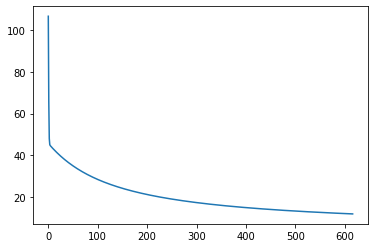

```python
theta, evol = grad_descent(x_train, y_train)  # Perform gradient descent
plt.plot(evol);  # Plot evolution of loss: does this seem correct?
### BEGIN HIDDEN TESTS
assert len(evol) < 800  # Test if you implemented the stopping criterion
assert evol[-1] - evol[-2] < 0.01  # Test if you implemented the stopping criterion
### END HIDDEN TESTS
```

**Question 6:**

**6.a. (0.5pt)** What is the training error rate, defined in classification as the percentage of predicted labels different from the true ones, of the logistic regression on the training dataset? Put the result in `training_error`.

```python
# training_error = ...  # <- TO UNCOMMENT AND COMPLETE

### BEGIN SOLUTION
# We store predictions for each x in x_train in a numpy array.
# Since the labels have a value of either 0 or 1,
# we can compute the percentage by summing the number of labels that differ
# divided by the total number of labels in y_train.
predictions = np.array([pred(x, theta) for x in x_train])
training_error = np.sum(np.abs(predictions - y_train)) / y_train.shape[0]
### END SOLUTION
```

```python
assert 0 <= training_error <= 1  # Must be between 0 and 1
### BEGIN HIDDEN TESTS
assert round(training_error, 2) == 0.01
### END HIDDEN TESTS
```

**6.b. (0.5pt)** What is the test error rate, defined in classification as the percentage of predicted labels different from the true ones, of the logistic regression on the test dataset? Put the result in `test_error`.

```python
# test_error = ...  # <- TO UNCOMMENT AND COMPLETE

### BEGIN SOLUTION
# As above but this time for the test set.
predictions = np.array([pred(x, theta) for x in x_test])
test_error = np.sum(np.abs(predictions - y_test)) / y_test.shape[0]
### END SOLUTION
```

```python
assert 0 <= test_error <= 1  # Must be between 0 and 1
### BEGIN HIDDEN TESTS
assert test_error == 0
### END HIDDEN TESTS
```

# Exercise 3: $k$-nearest neighbors

We briefly recall the $k$-nearest neighbors ($k$-NN) algorithm seen in lab session 2.

Consider a dataset $\mathcal{D} = (X, y)$ where the $j$-th coordinate of the $i$-th observation is denoted by $x^{(i)}_j$ and the corresponding label is $y^{(i)}$, or equivalently: $$\boldsymbol{X} = \begin{pmatrix} x_1^{(1)} & \dots & x_p^{(1)} \\ \vdots & \dots & \vdots \\ x_1^{(n)} & \dots & x_p^{(n)} \end{pmatrix} \quad \quad \boldsymbol{y} = \begin{pmatrix} y^{(1)} \\ \vdots \\ y^{(n)} \end{pmatrix}.$$

Fix an integer $k$. Given a new observation $x \in \mathbb{R}^p$, we predict its class $\hat{y}$ in the following way.

Let $x^{(i_1)}, \dots, x^{(i_k)}$ be the $k$ observations in $X$ which minimize the Euclidean distance $\|x - x^{(i)}\|_2$.

In classification, we choose $\hat{y}$ as the dominant occurence among the corresponding classes $\{ y^{(i_1)}, \dots, y^{(i_k)} \}$ (majority vote). In case of a tie, i.e., two (or more) classes are the most frequent, $\hat{y}$ is chosen randomly (uniformly) among these equally dominant classes.

In regression, we compute $\hat{y}$ as the mean of the values of $\{ y^{(i_1)}, \dots, y^{(i_k)} \}$.

We generate some data so that you can test your implementations.

```python
knn_df = gen_d_regression_samples(n_samples=50, p=2)
```

```python
knn_df.head()
```

|  | x0 | x1 | y |
| --- | --- | --- | --- |
| 0 | 2.125533 | 2.580487 | 4.753365 |
| 1 | 1.500172 | 1.953499 | 3.150340 |
| 2 | 1.720134 | 1.638508 | 3.312711 |
| 3 | 1.779390 | 2.018341 | 3.921928 |
| 4 | 2.095151 | 2.308225 | 4.437891 |

## $1$-nearest neighbors regressor

**Question 1 (1pt):** Implement a function which takes as input a matrix `X_train` of shape `n x p`, corresponding values `y_train` (shape `n`) a new observation `x` of shape `p`, and which returns a prediction of `y_hat` for this new observation using the **one**-nearest neighbor algorithm.

*Python hint:* You can compute the norm of a numpy array using `np.linalg.norm`. You can use `np.argmin` (resp. `np.argmax`) to find the index of the minimum (resp. maximum) of a numpy array.

```python
def oneNN(X_train: np.array, y_train: np.array, x: np.array) -> int:
    """
    Search nearest neighbor of x in X_train and output its predicted label

    :param numpy.array X_train: training dataset of shape N x p
    :param numpy.array y_train: training labels of shape N
    :param numpy.array x: test point of shape p
    :return: y_hat, class prediction
    :rtype: int
    """
    # First, we construct a list of distances from x to each data point in X_train.
    # Each distance is computed using np.linalg.norm(x - x_train).
    # Then, we predict y_hat label by choosing the label of the closest point in X_train (1-NN).
    # The smallest distance is the min in the list. However, we don't need the distance itself but its position.
    ### BEGIN SOLUTION
    # We thus use np.argmin instead, and finally we look up the corresponding label in y_train and return it.
    y_hat = y_train[np.argmin([np.linalg.norm(x - x_train) for x_train in X_train])]
    return y_hat
    ### END SOLUTION
```

Test your function by running the following cell (note that `df` is a DataFrame and we require a numpy array).

```python
# Print the value y_hat corresponding to the closest point in knn_df to the origin
print(oneNN(knn_df[['x0', 'x1']].to_numpy(),
            knn_df['y'].to_numpy(), np.array((0,0))))
### BEGIN HIDDEN TESTS
assert int(oneNN(knn_df[['x0', 'x1']].to_numpy(),
                 knn_df['y'].to_numpy(), np.array((0,0)))) == 3
assert int(oneNN(knn_df[['x0', 'x1']].to_numpy(),
                 knn_df['y'].to_numpy(), np.array((1,1)))) == 3
### END HIDDEN TESTS
```

```
3.2427830598521283
```

**Question 2 (1pt):** What is the training error (recall that in classification, it is the proportion of misclassified points in the training dataset; in regression, the squared sum of errors) achieved by this **algorithm** for $k=1$?

*Hint*: you can try returning `y_hat` from your previous function for `x in X_train` and compare it to `y_train` to give you an idea in the following cell (optional), and explain your answer in the subsequent cell (mandatory).

```python
### BEGIN SOLUTION
# We construct a list of predictions using oneNN classifier for each x_test data point in df, and convert it to a numpy array.
# Then, we subtract df['y'], the correct labels, from the predicted labels, and check if the result is 0. 0 means no error.
# Finally, np.all verifies if all the entries in the resulting array evaluate to True (no error).
np.all([oneNN(knn_df[['x0', 'x1']].to_numpy(),
              knn_df['y'].to_numpy(), x_test) for x_test in knn_df[['x0', 'x1']].to_numpy()] - knn_df['y'] == 0)
### END SOLUTION
```

```
True
```

The training error is 0 since in the training sample, the nearest-neighbor of a point is itself (except for pathological cases where similar points have different labels).

## $k$-nearest neighbors classifier

**Question 3 (1pt):** Is the $k$-NN algorithm a *parametric* or *non-parametric* model?

$k$-NN is a non-parametric model. It does not assume a particular functional form between the inputs and the outputs. $k$ is considered a *meta* or *hyper* parameter.

We go back to the iris dataset (in particular, its two first features):

```python
x_train, x_test, y_train, y_test = sk.model_selection.train_test_split(iris.data[:, :2],
                                                                       iris.target,
                                                                       test_size=1/4,
                                                                       random_state=1)
```

**Question 4 (1pt):** In this question, we allow the use of the `scikit-learn` library.

**4.a.** Using the library, perform $k$-NN classification for all $k = 1 \dots 20$ by training on (`x_train`, `y_train`), and use it to predict labels for `x_train` and `x_test`. Evaluate the quality of the classification using the `accuracy_score` function provided by `scikit-learn`. Store the results in two lists, `accuracy_scores_train` and `accuracy_scores_test`, which should contain, for $k = 1 \dots 20$, the error rate (evaluated by `accuracy_score`) on `x_train` and `x_test` respectively.

We recall how to perform $k$-NN classification using `scikit-learn`:

- `clf = KNeighborsClassifier(n_neighbors=k)` instantiates an object `clf` of the class `classifier`, which can be used to perform `n_neighbors`-NN classification (of course, you have to provide the value of `k` when instantiating the classifier).
- `clf.fit(x_train, y_train)` trains this classifier on a training set, where `x_train` is the observation matrix, `y_train` contains the labels.
- `y_pred = clf.predict(x_test)` for a new set of observations, encoded as a matrix `x_test`, returns label predictions `y_pred`.
- `accuracy_score(y_true, y_pred)` given the true labels of the test set `y_true` (`y_test` here) and the labels `y_pred` predicted by the $k$-NN classifier, computes the accuracy score of the classification.

```python
# accuracy_scores_train = ...  # <- TO UNCOMMENT AND COMPLETE
# accuracy_scores_test = ...  # <- TO UNCOMMENT AND COMPLETE

### BEGIN SOLUTION
accuracy_scores_train = []
accuracy_scores_test = []
# We loop for k in range 1 to 21 (range in Python doesn't include the right endpoint, so the interval is without 21)
# We instantiate KNeighborsClassifier with k neighbors.
# We fit the classifier.
# We append the accuracy score on the predictions of the classifier on both training and test sets,
# to accuracy_scores_train and accuracy_scores_test lists, respectively.
for k in range(1,21):
    clf = KNeighborsClassifier(n_neighbors=k)
    clf.fit(x_train, y_train)
    accuracy_scores_train.append(accuracy_score(y_train, clf.predict(x_train)))
    accuracy_scores_test.append(accuracy_score(y_test, clf.predict(x_test)))
### END SOLUTION
```

```python
assert len(accuracy_scores_train) == 20  # Did you compute 20 values of k?
assert np.max(accuracy_scores_train) <= 1  # The proportion should be between 0 and 1
assert np.min(accuracy_scores_train) >= 0  # The proportion should be between 0 and 1
```

You can plot the accuracies on the same graph w.r.t. to $k$ using the following cell:

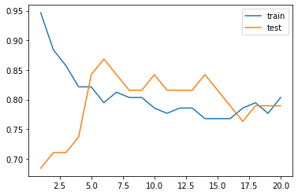

```python
plt.plot(range(1,21), accuracy_scores_train, label='train')
plt.plot(range(1,21), accuracy_scores_test, label='test')
plt.legend()
plt.show()
```

**4.b. (0.5pt)** Which value(s) of $k$ yield(s) the best accuracy on the test set?

$k = 6$ works best.

**N.B.:** Note that 1-NN training error *can* (in this rather extreme setting) be above 0 (like here) if two identical samples (in terms of covariates `x`) have different class labels.

**4.c. (0.5pt)** What is the phenomenon you are witnessing for $k > 6$?

Underfitting.

**4.d. (0.5pt)** What is the phenomenon you are witnessing for $k < 6$?

Overfitting.